# Part II - (Relationship between Subscribers and Customers, and what is unique about each of them.)

## by (Victor Onoja)

## Investigation Overview

> In this investigation, I want to know how the subscribers and customers user type differ. My main focus on on the daily usage, duration and gender.

## Dataset Overview

> This data set includes information about individual rides made in a bike-sharing system covering the greater San Francisco Bay area.

## (Subscribers and Customers daily usage)

> From our investigation, Subscribers take more daily trips than Customers with the Highest peak on Thursday followed by the rest of the week days. On weekends bike trips a less.

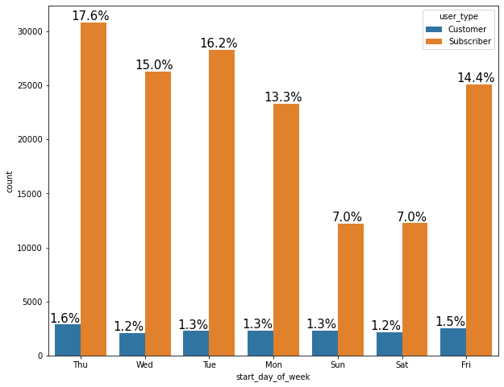

## (Subscribers and Customers trip duration)

> From this visualization, we can see that Customers have high trip durations compare to Subscribers. And this is the reason why I believe Customers are called 'Customers' in this case, it is because of their trip duration. Customers are not even up to 1/3 as much as subscribers but when they do go for a ride, their duration is above average.

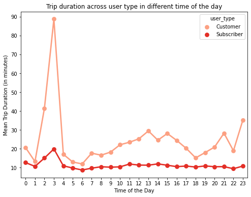

## (Subscribers and Customers across genders using FordGoBike)

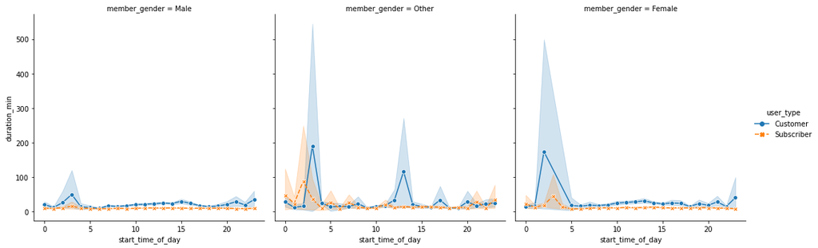